# Martingales and Stopping Times

## 1. A stopping time uses only current information

A filtration $(\mathcal F_n)_{n\geq0}$ records the information available through time $n$. A random time $\tau$ is a stopping time when

$$ \{\tau\leq n\}\in\mathcal F_n \qquad\text{for every }n. $$

Thus the decision to stop by time $n$ can be made from the information already observed. If $M=(M_n)$ is a martingale, then the stopped process

$$ M_n^\tau=M_{n\wedge\tau} $$

is again a martingale. This statement does not yet identify $E[M_\tau]$: passing from $M_{n\wedge\tau}$ to $M_\tau$ requires a convergence argument.

For a symmetric random walk $S_n=\sum_{j=1}^n\xi_j$ with $P(\xi_j=1)=P(\xi_j=-1)=1/2$, consider

$$ \tau=\inf\{n\geq0:S_n=A\text{ or }S_n=-B\}. $$

The boundary crossing is observable when it occurs, so $\tau$ is a stopping time.

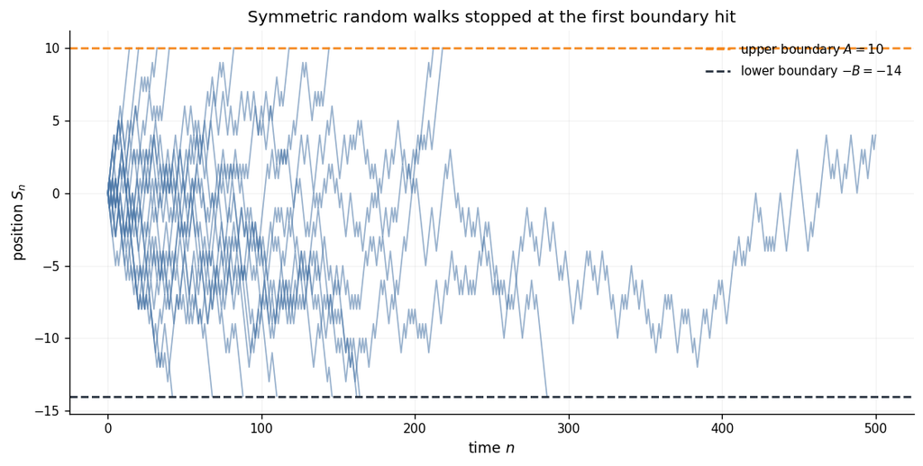

**Figure 1.** Symmetric random-walk paths stopped on first reaching $A=10$ or $-B=-14$.

Interpretation. Each path is drawn only until its boundary hit. The stopping rule depends on the observed path up to the current time, and the resulting stopped process remains inside the bounded interval $[-B,A]$.

## 2. Optional stopping solves bounded gambler's ruin

Because $S_{n\wedge\tau}$ is bounded by $\max(A,B)$, the family is uniformly integrable. Hence

$$ E[S_\tau]=E[S_0]=0. $$

Writing $u=P(S_\tau=A)$ gives

$$ 0=Au-B(1-u), \qquad u=\frac{B}{A+B}. $$

The process $S_n^2-n$ is also a martingale. Applying optional stopping to $\tau\wedge N$ and then passing to the limit under the finite-expectation argument for this bounded-interval exit yields

$$ E[\tau]=E[S_\tau^2]=AB. $$

The experiment compares both identities with Monte Carlo estimates. The error bars are approximate pointwise $95\%$ Monte Carlo intervals; they do not represent discretisation error because this random walk is simulated exactly.

```
Maximum absolute hitting-probability error: 0.00560
Maximum relative mean-time error: 0.495%
```

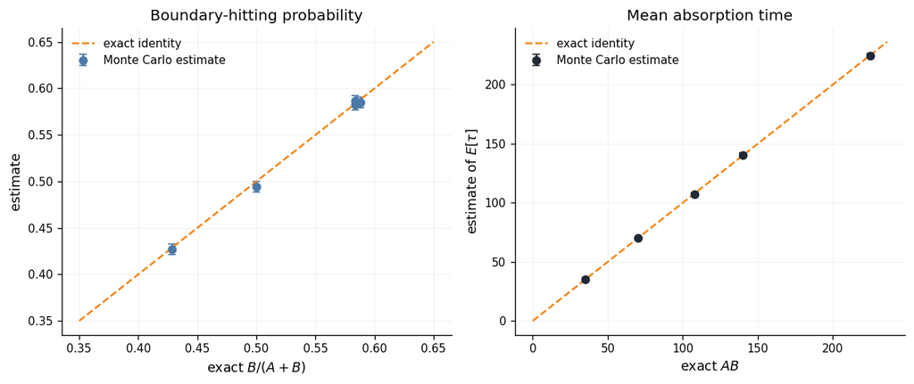

**Figure 2.** Boundary-hitting probabilities and mean absorption times for five bounded symmetric random walks, with approximate pointwise $95\%$ Monte Carlo intervals.

Interpretation. The estimates lie close to the exact identities $P(S_\tau=A)=B/(A+B)$ and $E[\tau]=AB$. Optional stopping supplies the identities; the simulation reports their finite-sample numerical agreement.

## 3. A tilted martingale handles biased walks

Let $P(\xi_j=1)=p$, $P(\xi_j=-1)=q=1-p$, and suppose $p\neq1/2$. The walk $S_n$ has non-zero drift, but

$$ M_n=\left(\frac{q}{p}\right)^{S_n} $$

is a non-negative martingale. At the bounded-interval stopping time $\tau$, the stopped process $M_{n\wedge\tau}$ is bounded. Optional stopping therefore gives

$$ P(S_\tau=A) =\frac{1-(q/p)^B}{1-(q/p)^{A+B}}. $$

As $p\to1/2$, this expression converges to the symmetric probability $B/(A+B)$.

```
Maximum absolute probability error: 0.00420
```

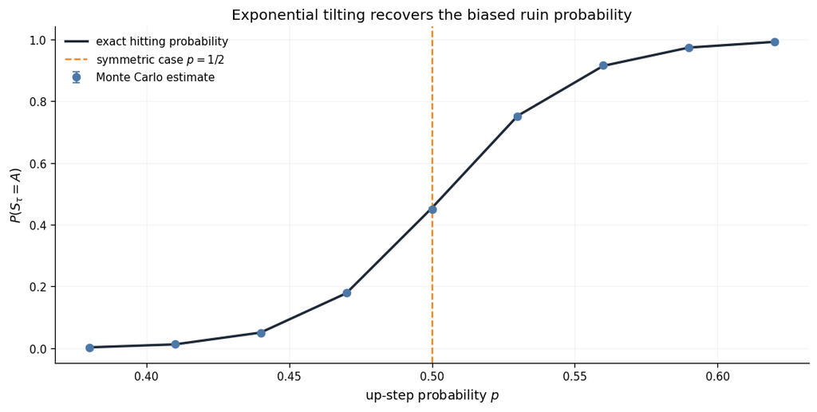

**Figure 3.** Exact and simulated probabilities of hitting $A=12$ before $-B=-10$ as the up-step probability $p$ varies, with approximate pointwise $95\%$ Monte Carlo intervals.

Interpretation. Increasing $p$ shifts mass toward the upper boundary, and the exponential-martingale formula follows the transition through the symmetric case. The numerical estimates are consistent with the exact probabilities at Monte Carlo scale.

## 4. An unbounded stopping time exposes the missing hypothesis

For a symmetric random walk starting from zero, define

$$ \tau=\inf\{n\geq0:S_n=1\}. $$

This stopping time is finite almost surely and $S_\tau=1$, so $E[S_\tau]=1$. For every fixed $N$, however, the bounded stopping time $\tau\wedge N$ satisfies

$$ E[S_{\tau\wedge N}]=0. $$

There is no contradiction: the family $(S_{\tau\wedge N})_N$ is not uniformly integrable, so expectation cannot be interchanged with the almost-sure limit. The survival curve below is estimated with right censoring handled explicitly. A path not observed to hit by `max_steps` counts as $\tau>n$ for every plotted $n<\texttt{max_steps}$.

```
Largest |estimated E[S_(tau wedge N)]|: 0.04898
Right-censored fraction at 200,000 steps: 0.00177
```

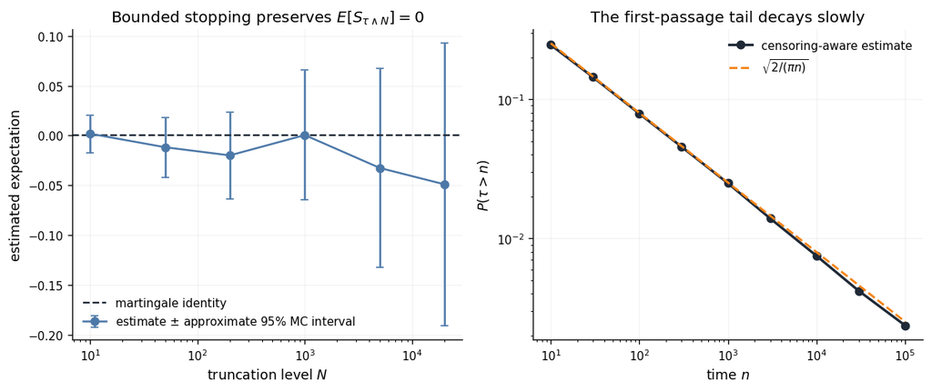

**Figure 4.** Bounded-stopping expectations and the censoring-aware survival curve for the first hitting time of $+1$.

Interpretation. Each bounded stopping rule preserves the martingale expectation, while the slowly decaying first-passage tail prevents uniform integrability as $N$ increases. The right panel counts every path still unresolved at the simulation horizon in the survival probability, avoiding the downward bias caused by deleting censored paths.

## 5. Continuous stopping and localization

If $M=(M_t)_{t\geq0}$ is a continuous martingale and $\tau$ is a stopping time, then $M_{t\wedge\tau}$ is again a martingale. For Brownian motion and the interval-exit time

$$ \tau_{A,B}=\inf\{t\geq0:B_t=A\text{ or }B_t=-B\}, $$

optional stopping applied with the required integrability gives

$$ P(B_{\tau_{A,B}}=A)=\frac{B}{A+B}, \qquad E[\tau_{A,B}]=AB. $$

The simulation observes Brownian motion only at times $k\Delta t$. It therefore computes the grid-monitored exit

$$ \tau_{A,B}^{\Delta t} =\inf\{k\Delta t:B_{k\Delta t}\geq A\text{ or }B_{k\Delta t}\leq-B\}, $$

which can miss a crossing between observations and can overshoot the boundary. The difference from the continuous-time benchmark is discretisation and monitoring error.

This stopping principle also underlies localization. A process $M$ is a local martingale when there are stopping times $T_n\uparrow\infty$ such that every $M^{T_n}$ is a martingale. Passing from the stopped martingales to a global martingale requires an additional condition such as domination by an integrable random variable.

```
Continuous-time P(hit upper first): 0.40000
Finest-grid estimate:               0.40071
Continuous-time E[tau]:             0.96000
Finest-grid estimate:               0.99249
```

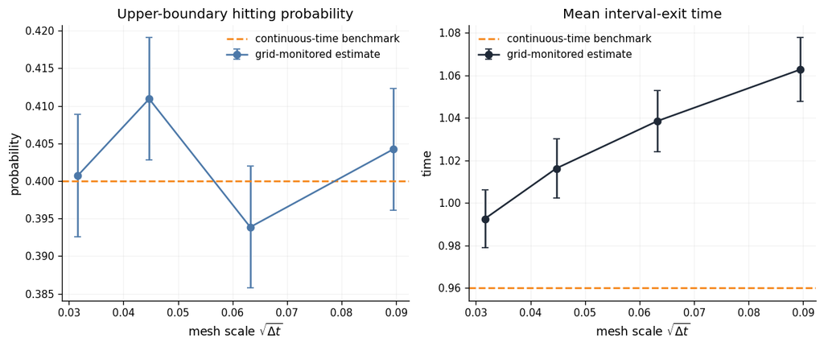

**Figure 5.** Grid-monitored Brownian exit estimates at four time meshes, compared with the continuous-time hitting-probability and mean-exit-time identities.

Interpretation. Finer observation meshes reduce the boundary overshoot and missed-crossing effects. The intervals quantify Monte Carlo uncertainty at each mesh; movement across meshes records discretisation and monitoring error, so the finest-grid estimate remains an approximation to the continuous stopping-time quantity.

## References

- *MATH3015: Stochastic Processes*, Chapter 2, Definition 2.11, Theorem 2.12, and the gambler's-ruin derivation around equations (2.3)-(2.4); Chapter 3, Theorem 3.13.
- Fima C. Klebaner, *Introduction to Stochastic Calculus with Applications*, 3rd ed., Chapter 7, Sections 7.2, 7.4, and 7.5, especially Theorem 7.18 on optional sampling and Theorem 7.21 on dominated local martingales.